# Country-Level Predictors of Confidence in Social Institutions

A World Values Survey analysis with a focus on Japan

Hugh Trinh

September 2026

## About this piece

This notebook is a personal, restructured version of a data analytics assignment I completed (FIT3152, Monash University): analysing country-level predictors of confidence in social institutions using the World Values Survey (WVS) Wave 7 data.

My assigned focus country is **Japan (JPN)**. The four themes are:

1. **Data overview & quality:** what the survey extract looks like before any modelling.
2. **How Japan differs from the rest of the world:** a multivariate comparison of average responses.
3. **Finding a cluster of countries similar to Japan:** using external governance indicators (World Bank WGI) and k-means.
4. **Predicting confidence in social institutions:** comparing how well participant attributes predict institutional confidence for Japan alone, for the rest of the world pooled together, and for Japan’s cluster of similar countries.

## Setup and data

The data is a per-student random subset of the WVS Wave 7 extract: 50,000 respondents and a personally-assigned set of 40 columns (a fixed 13 identifier/demographic columns, 17 randomly sampled “value/attitude” predictors, and 10 randomly sampled confidence-in-institutions outcomes), drawn with a seed tied to my student ID so the subset is reproducible.

```r
library(ggplot2)
library(GGally)
library(tidyr)
library(reshape2)

id <- as.numeric(Sys.getenv("STUDENT_ID"))
set.seed(id)
VCData = read.csv("WVSExtract.csv")
VC = VCData[sample(1:nrow(VCData), 50000, replace = FALSE), ]
VC = VC[, c(1:6, sort(sample(7:46, 17, replace = FALSE)), 47:53,
            sort(sample(54:69, 10, replace = FALSE)))]
```

## Theme 1: Data overview and quality

The dataset has 50,000 observations across 40 variables. All variables are integer-coded except `Country`, which is character (the ISO3 country code).

```r
dim(VC)
```

```
## [1] 50000    40
```

```r
str(VC)
```

```
## 'data.frame':    50000 obs. of  40 variables:
##  $ Country       : chr  "DEU" "AUS" "MAC" "TUR" ...
##  $ TPeople       : int  1 1 2 2 2 1 1 2 1 2 ...
##  $ TFamily       : int  2 1 1 1 1 1 1 2 1 1 ...
##  $ TNeighbourhood: int  2 2 1 3 2 2 2 3 2 2 ...
##  $ TKnow         : int  2 1 2 2 1 2 1 1 2 3 ...
##  $ TMeet         : int  3 3 3 4 2 3 2 2 3 2 ...
##  $ VFamily       : int  1 1 1 1 1 1 1 2 1 1 ...
##  $ VWork         : int  2 2 2 2 1 2 2 1 3 2 ...
##  $ VReligion     : int  3 4 2 3 2 3 3 1 1 2 ...
##  $ HChoice       : int  9 6 6 7 8 5 8 8 4 3 ...
##  $ HFood         : int  4 4 4 3 4 4 4 4 4 1 ...
##  $ HCrime        : int  3 4 4 3 4 4 4 4 4 2 ...
##  $ HShelter      : int  4 4 4 3 4 4 4 4 4 2 ...
##  $ EEquality     : int  7 2 6 3 6 6 10 6 7 2 ...
```

[output cut: 26 more lines]

There are 65 countries in the dataset, and the number of respondents per country varies quite a lot. This is a real imbalance to keep in mind for anything that pools countries together.

```r
length(unique(VC$Country))            # Number of countries
```

```
## [1] 65
```

```r
min(table(VC$Country))                # Lowest number of instances by country
```

```
## [1] 510
```

```r
max(table(VC$Country))                # Highest number of instances by country
```

```
## [1] 2085
```

Cyprus (CYP) appears the least, with 510 respondents, while Canada (CAN) appears the most, with 2,085.

Looking at `summary(VC)`, every numerical attribute has a minimum value of -5, which is not a real response. Per the WVS Wave 7 documentation, values from -5 to -1 are missing-data codes (refused, don’t know, not applicable, etc.), not genuine scale points.

```r
summary(VC)
```

```
##    Country             TPeople          TFamily       TNeighbourhood
##  Length:50000       Min.   :-5.000   Min.   :-5.000   Min.   :-5.000
##  Class :character   1st Qu.: 1.000   1st Qu.: 1.000   1st Qu.: 2.000
##  Mode  :character   Median : 2.000   Median : 1.000   Median : 2.000
##                     Mean   : 1.708   Mean   : 1.262   Mean   : 2.151
##                     3rd Qu.: 2.000   3rd Qu.: 1.000   3rd Qu.: 3.000
##                     Max.   : 2.000   Max.   : 4.000   Max.   : 4.000
##      TKnow            TMeet           VFamily           VWork
##  Min.   :-5.000   Min.   :-5.000   Min.   :-5.000   Min.   :-5.000
##  1st Qu.: 2.000   1st Qu.: 2.000   1st Qu.: 1.000   1st Qu.: 1.000
##  Median : 2.000   Median : 3.000   Median : 1.000   Median : 1.000
##  Mean   : 2.036   Mean   : 2.948   Mean   : 1.107   Mean   : 1.509
##  3rd Qu.: 2.000   3rd Qu.: 4.000   3rd Qu.: 1.000   3rd Qu.: 2.000
##  Max.   : 4.000   Max.   : 4.000   Max.   : 4.000   Max.   : 4.000
##    VReligion         HChoice           HFood            HCrime
##  Min.   :-5.000   Min.   :-5.000   Min.   :-5.000   Min.   :-5.000
##  1st Qu.: 1.000   1st Qu.: 6.000   1st Qu.: 3.000   1st Qu.: 3.000
##  Median : 2.000   Median : 7.000   Median : 4.000   Median : 4.000
##  Mean   : 1.948   Mean   : 7.136   Mean   : 3.464   Mean   : 3.414
##  3rd Qu.: 3.000   3rd Qu.: 9.000   3rd Qu.: 4.000   3rd Qu.: 4.000
##  Max.   : 4.000   Max.   :10.000   Max.   : 4.000   Max.   : 4.000
##     HShelter        EEquality       ECompetition      EHardWork
##  Min.   :-5.000   Min.   :-5.000   Min.   :-5.000   Min.   :-5.000
##  1st Qu.: 4.000   1st Qu.: 4.000   1st Qu.: 1.000   1st Qu.: 1.000
##  Median : 4.000   Median : 7.000   Median : 4.000   Median : 4.000
##  Mean   : 3.679   Mean   : 6.162   Mean   : 3.973   Mean   : 4.384
##  3rd Qu.: 4.000   3rd Qu.: 9.000   3rd Qu.: 6.000   3rd Qu.: 7.000
##  Max.   : 4.000   Max.   :10.000   Max.   :10.000   Max.   :10.000
##     SSecure            SJob           STRight       STImportant
##  Min.   :-5.000   Min.   :-5.000   Min.   :-5.00   Min.   :-5.000
##  1st Qu.: 1.000   1st Qu.: 1.000   1st Qu.: 3.00   1st Qu.: 2.000
##  Median : 2.000   Median : 2.000   Median : 5.00   Median : 4.000
##  Mean   : 1.981   Mean   : 1.949   Mean   : 5.07   Mean   : 4.353
##  3rd Qu.: 2.000   3rd Qu.: 3.000   3rd Qu.: 8.00   3rd Qu.: 7.000
##  Max.   : 4.000   Max.   : 4.000   Max.   :10.00   Max.   :10.000
##    PNewspaper      PTelevision        PMobile         PDemImp
##  Min.   :-5.000   Min.   :-5.000   Min.   :-5.00   Min.   :-5.000
##  1st Qu.: 2.000   1st Qu.: 1.000   1st Qu.: 1.00   1st Qu.: 7.000
##  Median : 4.000   Median : 1.000   Median : 1.00   Median : 9.000
##  Mean   : 3.307   Mean   : 1.812   Mean   : 2.38   Mean   : 8.186
```

[output cut: 15 more lines]

```
##  Max.   : 8.000   Max.   : 8.00   Max.   : 4.000   Max.   : 4.000
##   CTelevision        CPolice          CCourts         CPParties
##  Min.   :-5.000   Min.   :-5.000   Min.   :-5.000   Min.   :-5.000
##  1st Qu.: 2.000   1st Qu.: 2.000   1st Qu.: 2.000   1st Qu.: 2.000
##  Median : 3.000   Median : 2.000   Median : 2.000   Median : 3.000
##  Mean   : 2.567   Mean   : 2.219   Mean   : 2.255   Mean   : 2.827
##  3rd Qu.: 3.000   3rd Qu.: 3.000   3rd Qu.: 3.000   3rd Qu.: 4.000
##  Max.   : 4.000   Max.   : 4.000   Max.   : 4.000   Max.   : 4.000
##  CUniversities     CElections         CBanks          CEnvOrg
##  Min.   :-5.00   Min.   :-5.000   Min.   :-5.000   Min.   :-5.000
##  1st Qu.: 1.00   1st Qu.: 2.000   1st Qu.: 2.000   1st Qu.: 2.000
##  Median : 2.00   Median : 3.000   Median : 2.000   Median : 2.000
##  Mean   : 2.01   Mean   : 2.406   Mean   : 2.313   Mean   : 2.142
##  3rd Qu.: 3.00   3rd Qu.: 3.000   3rd Qu.: 3.000   3rd Qu.: 3.000
##  Max.   : 4.00   Max.   : 4.000   Max.   : 4.000   Max.   : 4.000
```

To see how missing values are distributed across attributes, I count how many values of each predictor fall in the negative (missing-code) range:

```r
count_missing = function() {
  counts = data.frame(country = character(), missing_count = numeric(), percentage = numeric())
  for (col in names(VC[, -1])) {
    count = colSums(VC[, -1] < 0)[col]
    counts[nrow(counts) + 1, ] = data.frame(
      country = col,
      missing_count = count,
      percentage = count / nrow(VC) * 100
    )
  }
  rownames(counts) = NULL
  return(counts)
}
missing_values = count_missing()
head(missing_values)
```

|  | country | missing_count | percentage |
| --- | --- | --- | --- |
| 1 | TPeople | 663 | 1.326 |
| 2 | TFamily | 161 | 0.322 |
| 3 | TNeighbourhood | 405 | 0.810 |
| 4 | TKnow | 295 | 0.590 |
| 5 | TMeet | 707 | 1.414 |
| 6 | VFamily | 86 | 0.172 |

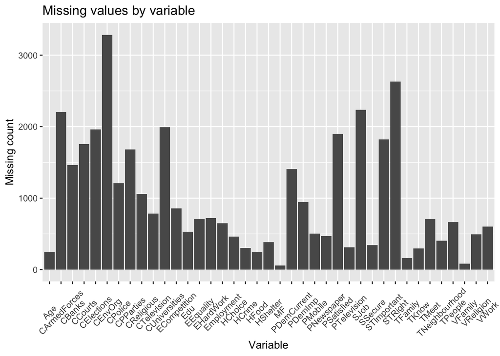

Figure 1: Missing value count by variable

```r
ggplot(missing_values, aes(x = country, y = missing_count)) +
  geom_bar(stat = "identity") +
  theme(axis.text.x = element_text(angle = 45, vjust = 0.5, hjust = 0.5)) +
  labs(x = "Variable", y = "Missing count", title = "Missing values by variable")
```

The number of missing values varies quite a bit from attribute to attribute. Respondent’s sex (`MF`) has the fewest missing values (55 instances, 0.11%) whereas confidence in environmental protection movements (`CEnvOrg`) has the most, at 3,287 (6.57%) of all responses. Confidence-related questions and the science/technology-attitude questions tend to sit at the higher end, while demographic and trust questions tend to sit at the lower end.

For everything that follows, I replace the missing-data codes with proper `NA`s so they don’t get treated as real responses:

```r
VC[VC < 0 & VC >= -5] = NA
```

## Theme 2: How does Japan differ from the rest of the world?

To see how Japanese respondents compare to everyone else, I split the sample into “JPN” and “Others”, z-score standardise every numeric variable (so variables on very different scales are comparable), and take the average response of each group.

```r
scaled_VC = as.data.frame(lapply(VC, function(col) {
  if (is.numeric(col)) scale(col) else col
})) # Scaling data

VC_JPN_Others_raw = VC
VC_JPN_Others_raw$Country = ifelse(VC$Country == "JPN", "JPN", "Others")

VC_JPN_Others = scaled_VC
VC_JPN_Others$Country = ifelse(VC$Country == "JPN", "JPN", "Others")
response_JPN_Others = t(aggregate(. ~ Country, VC_JPN_Others, mean)[, -1])
colnames(response_JPN_Others) = c("JPN", "Others")
```

The heat map below shows the (standardised) difference between the average Japanese response and the average response from every other country pooled together.

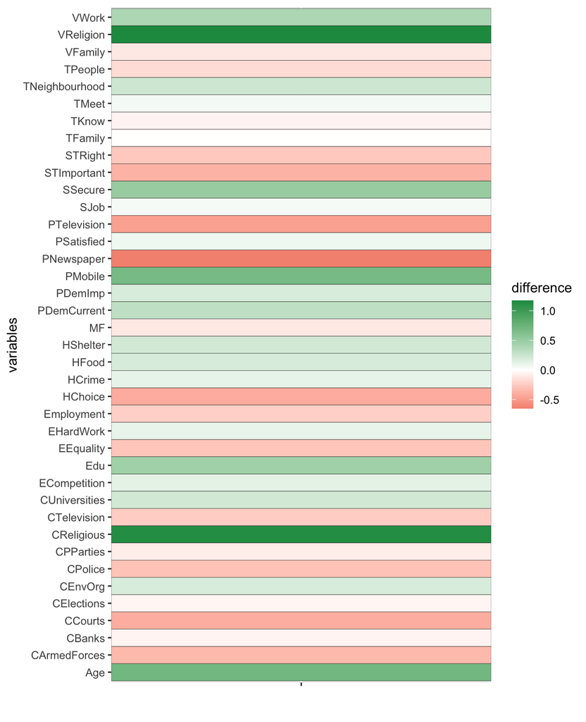

Figure 2: Differences between responses in Japan and responses in other countries

```r
heat_map_difference = function(data, col_1, col_2) {
  difference = data[, col_1] - data[, col_2]
  heat_map_data = data.frame(variables = rownames(data), difference = difference)
  return(ggplot(heat_map_data, aes(x = "", y = variables, fill = difference)) +
           geom_tile(color = "black", width = 2) +
           scale_fill_gradient2(
             low = "#D73027",
             mid = "white",
             high = "#1A9850"
           ) +
           labs(x = ""))
}
heat_map_difference(response_JPN_Others, "JPN", "Others")
```

Quite a few variables show a substantial difference. The most noticeable is `VReligion` (importance of religion in life), which has the largest positive difference: religion matters more to Japanese respondents than to respondents elsewhere. `CReligious` (confidence in religious institutions) shows the same pattern, which lines up with the `VReligion` result. `VWork` (importance of work) is also higher, while `VFamily` (importance of family) is slightly *lower*. On average, Japanese respondents place a bit less emphasis on family relative to the rest of the world.

Age also stands out: the average age of Japanese respondents (53.5) is noticeably higher than the international average (41.7), reflecting Japan’s older population.

On the negative side, `PNewspaper` and `PTelevision` (frequency of using newspapers/TV as an information source) both register red on the heat map, but for these variables, a *lower* value means more frequent use, so this actually means Japanese respondents consume news from newspapers and television more often than respondents elsewhere.

`HChoice` (how much control people feel they have over their own life, 1 = none, 10 = a great deal) is also clearly lower for Japan, suggesting Japanese respondents feel they have less control over their lives on average than respondents elsewhere. Variables like `TFamily`, `SJob`, and `TMeet` sit close to zero, meaning Japan looks fairly similar to the rest of the world on those.

## Theme 3: Finding a cluster of countries similar to Japan

Rather than comparing Japan to *every* other country as one undifferentiated group, it’s also worth asking which countries in the survey are genuinely similar to Japan, and whether comparing Japan to *those* countries specifically tells a different story. I use external governance data from the World Bank’s [Worldwide Governance Indicators](http://info.worldbank.org/governance/wgi/) (WGI), which includes Voice and Accountability, Regulatory Quality, Political Stability and Absence of Violence/Terrorism, Rule of Law, Government Effectiveness, and Control of Corruption. For each of those six dimensions I use six sub-indicators: the governance estimate itself, its standard deviation, the number of data sources it’s based on, its percentile rank, and the lower and upper bounds of its 90% confidence interval. That’s 36 indicators describing each country’s institutional quality, for the most recent year available (2022).

```r
wgi = read.csv("wgidataset.csv")
wgi = wgi[wgi["year"] == 2022, ]

wgi = pivot_wider(wgi,
  id_cols = c(code, countryname),
  names_from = indicator,
  values_from = c(estimate, stddev, nsource, pctrank, pctranklower, pctrankupper))
wgi = wgi[!apply(wgi == "..", 1, any), !(colnames(wgi) %in% c("codeindyr", "year"))]
wgi = as.data.frame(wgi)
```

A couple of country codes don’t match between the two datasets:

```r
unique(VC$Country)[!(unique(VC$Country) %in% wgi$code)]
```

```
## [1] "ROU" "AND"
```

`ROU` (Romania) is coded `ROM` in the WGI data, and `AND` (Andorra) is coded `ADO`, so I fix those before filtering the WGI data down to just the countries in my survey extract and scaling the indicators:

```r
wgi$code[wgi$code == "ROM"] = "ROU"
wgi$code[wgi$code == "ADO"] = "AND"

wgi = wgi[wgi$code %in% unique(VC$Country), ]
rownames(wgi) = wgi$code
wgi[, 3:length(wgi)] = sapply(wgi[, 3:length(wgi)], function(col) as.numeric(col))
wgi[, 3:length(wgi)] = scale(wgi[, 3:length(wgi)])
nrow(wgi)
```

```
## [1] 65
```

I fit k-means with $k = \lfloor n/5 \rfloor$ clusters (a rule of thumb aiming for groups of around 5 countries), with 20 random starts to stabilise the result:

```r
id <- as.numeric(Sys.getenv("STUDENT_ID"))
set.seed(id)
country_fit = kmeans(wgi[, 3:length(wgi)], floor(nrow(wgi[, 3:length(wgi)]) / 5), nstart = 20)
table(country_fit$cluster)
```

```
##
##  1  2  3  4  5  6  7  8  9 10 11 12 13
## 11  7  2  1  6  3 11  5  5  5  2  5  2
```

```r
country_fit$cluster["JPN"]
```

```
## JPN
##   1
```

```r
cluster_countries = names(country_fit$cluster[country_fit$cluster == country_fit$cluster["JPN"]])
cluster_countries
```

```
##  [1] "AUS" "CAN" "DEU" "JPN" "KOR" "NLD" "NZL" "TWN" "GBR" "USA" "URY"
```

Japan’s cluster contains 11 countries: **Australia, Canada, Germany, Japan, South Korea, the Netherlands, New Zealand, Taiwan, the United Kingdom, the United States, and Uruguay**. These are mostly high-income, high-governance-quality democracies, which makes intuitive sense given the indicators used.

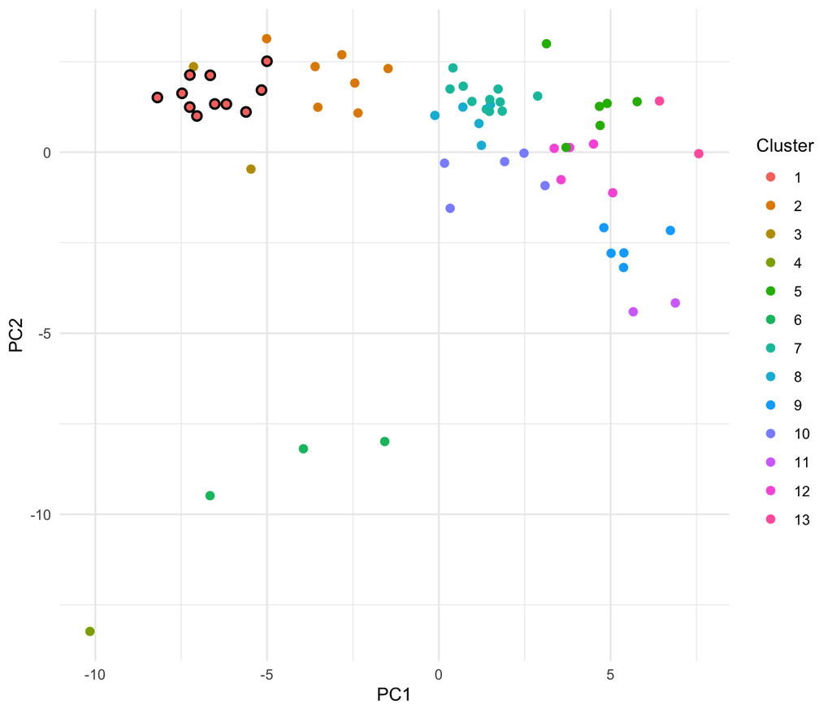

Figure 6: Visualisation of the k-means clusters (first two principal components), Japan’s cluster outlined in black

```r
pca = prcomp(wgi[, 3:length(wgi)], scale. = TRUE)
pca_df = data.frame(
  pca$x[, 1:2],
  Cluster = factor(country_fit$cluster),
  Country = wgi$code)
jpn_cluster_id = country_fit$cluster["JPN"]

ggplot(pca_df, aes(PC1, PC2, color = Cluster)) +
  geom_point(size = 2) +
  geom_point(data = subset(pca_df, Cluster == jpn_cluster_id),
             aes(PC1, PC2),
             shape = 21, fill = NA, color = "black", size = 2, stroke = 1) +
  theme_minimal()
```

Japan’s cluster (outlined) sits clearly apart from the bulk of countries along the first principal component, which broadly separates higher- from lower-governance-quality countries.

## Theme 4: Predicting confidence in social institutions

This is the central question of the assignment: how well do participant attributes (trust, values, life satisfaction, media use, demographics, etc.) predict confidence in each of the ten social institutions in my extract, and does that answer change depending on which group of countries the model is trained on?

### 4.1 Modelling approach

For each confidence variable (`CReligious`, `CArmedForces`, `CTelevision`, `CPolice`, `CCourts`, `CPParties`, `CUniversities`, `CElections`, `CBanks`, `CEnvOrg`), and for a given group of countries, I:

1. Keep only non-confidence predictors (everything *not* prefixed `C`), so one confidence variable is never used to predict another.
2. Split 70/30 into train/test.
3. Impute missing values with the training-set mean for that variable.
4. Z-score standardise predictors, using the training set’s mean/SD (and applying the *same* mean/SD to the test set, to avoid leaking test-set information into the transformation).
5. Fit a full linear regression model, then a bidirectional stepwise model (`step()`, by AIC) to get a more parsimonious model.
6. Evaluate both on the held-out test set with MSE, MAE, RMSE, R² (train and test), and an “accuracy” score: the predicted values rounded to the nearest integer and clipped to the observed range, then compared to the actual rounded response.

```r
lm_country = function(data, label_col, country) {
  data[data < 0 & data >= -5] = NA
  data = data[data$Country == country, ]
  data = data[, !(startsWith(names(data), "C")) | names(data) == label_col]
  train_rows = sample(nrow(data), floor(nrow(data) * 0.7))
  train_data = data[train_rows, ]
  test_data = data[-train_rows, ]
  for (i in 1:length(train_data)) {
    if (is.numeric(train_data[[i]])) {
      mean_NA = mean(train_data[[i]], na.rm = TRUE)
      train_data[[i]][is.na(train_data[[i]])] = mean_NA
      test_data[[i]][is.na(test_data[[i]])] = mean_NA
    }
  }
  x_train = train_data[, names(train_data) != label_col]
  y_train = train_data[, label_col]
  x_test = test_data[, names(test_data) != label_col]
  y_test = test_data[, label_col]
  fit_transformed = fit_transform(x_train)
  x_train = fit_transformed$scaled_data
  x_test = transform(
    x_test,
    fit_transformed$means,
    fit_transformed$sds
  )
  train_data = cbind(x_train, y_train)
  names(train_data)[ncol(train_data)] = label_col
  full_model = lm(as.formula(paste(label_col, "~ .")), data = train_data)
  step_model = step(full_model, direction = "both", trace = 0) # trace=0: suppress the AIC trace log
  output = list(
    model = full_model,
    x_test = x_test,
    y_test = y_test,
    step_model = step_model,
    train_data = train_data
  )
  return(output)
}

fit_transform = function(data) {
  means = sapply(
    data,
    function(col) if (is.numeric(col)) mean(col, na.rm = TRUE) else NA
  )
  sds = sapply(
    data,
    function(col) if (is.numeric(col)) sd(col, na.rm = TRUE) else NA
  )
  scaled_data = as.data.frame(mapply(function(col, mean, sd) {
    if (is.numeric(col)) {
      (col - mean) / sd
    } else {
      col
    }
  }, data, means, sds, SIMPLIFY = FALSE))
  output_list = list(scaled_data = scaled_data, means = means, sds = sds)
  return(output_list)
}

transform = function(data, means, sds) {
  for (col in names(data)) {
    if (is.numeric(data[[col]])) {
      mean = means[col]
      sd = sds[col]
      data[[col]] = (data[[col]] - mean) / sd
    }
  }
  return(data)
}
```

I wrap the per-variable loop (full model + stepwise model + metrics) into one function so it can be re-run identically for each group of countries, with its own seed for reproducibility:

```r
evaluate_group = function(data, group_label, seed) {
  set.seed(seed)
  eval = data.frame(label_col = character(), mse = numeric(), mae = numeric(),
                     r_squared_train = numeric(), r_squared_test = numeric(),
                     rmse = numeric(), accuracy = numeric())
  eval_full = eval
  lst = list()
  for (label_col in names(data)) {
    if (label_col != "Country" & startsWith(label_col, "C")) {
      res = lm_country(data, label_col, group_label)

      # Full model metrics
      full_model = res$model
      predictions_f = predict(full_model, newdata = res$x_test)
      r_squared_test_f = 1 - sum((res$y_test - predictions_f)^2) / sum((res$y_test - mean(res$y_test))^2)
      rounded_f = pmin(pmax(round(predictions_f), min(res$y_test)), max(res$y_test))
      eval_full = rbind(eval_full, data.frame(
        label_col = label_col,
        mse = mean((predictions_f - res$y_test)^2),
        mae = mean(abs(res$y_test - predictions_f)),
        r_squared_train = summary(full_model)$r.squared,
        r_squared_test = r_squared_test_f,
        rmse = sqrt(mean((res$y_test - predictions_f)^2)),
        accuracy = mean(rounded_f == res$y_test)
      ))

      # Stepwise model metrics
      step_model = res$step_model
      lst = append(lst, list(summary(step_model)))
      predictions = predict(step_model, newdata = res$x_test)
      rounded_predictions = round(predictions)
      rounded_predictions = pmin(pmax(rounded_predictions, min(res$y_test)), max(res$y_test))
      eval = rbind(eval, data.frame(
        label_col = label_col,
        mse = mean((predictions - res$y_test)^2),
        mae = mean(abs(res$y_test - predictions)),
        r_squared_train = summary(step_model)$r.squared,
        r_squared_test = 1 - sum((res$y_test - predictions)^2) / sum((res$y_test - mean(res$y_test))^2),
        rmse = sqrt(mean((res$y_test - predictions)^2)),
        accuracy = mean(rounded_predictions == res$y_test)
      ))
    }
  }
  names(lst) = eval$label_col
  return(list(eval = eval, eval_full = eval_full, lst = lst))
}

# Significant (p < 0.05) predictors for each dependent variable's stepwise model
significant_predictors = function(lst) {
  for (conf_ind in names(lst)) {
    summary_lm = as.data.frame(lst[[conf_ind]]$coefficients)["Pr(>|t|)"]
    rn = rownames(summary_lm)
    sig = rn[-1][summary_lm[-1, 1] < 0.05]
    cat("-", conf_ind, ": ", paste(sig, collapse = ", "), "\n\n")
  }
}

make_metric_heatmap = function(eval_df, title) {
  df = eval_df
  names(df) = c("Column", "MSE", "MAE", "R2 on training data", "R2 on testing data", "RMSE", "Accuracy")
  m = melt(df, id.vars = "Column")
  ggplot(m, aes(x = variable, y = Column, fill = value)) +
    geom_tile(color = "white") +
    scale_fill_gradient(low = "white", high = "lightblue") +
    labs(x = "Metric", y = "Dependent variable", title = title) +
    theme_minimal()
}
```

### 4.2 Japan alone

```r
res_jpn = evaluate_group(VC, "JPN", 4001)
```

**Full model** (all available predictors kept):

```r
round(res_jpn$eval_full[, -1], 3)
```

| mse | mae | r_squared_train | r_squared_test | rmse | accuracy |
| --- | --- | --- | --- | --- | --- |
| 0.301 | 0.448 | 0.372 | 0.169 | 0.549 | 0.551 |
| 0.351 | 0.437 | 0.176 | 0.099 | 0.592 | 0.597 |
| 0.399 | 0.508 | 0.141 | 0.055 | 0.632 | 0.532 |
| 0.378 | 0.450 | 0.250 | 0.024 | 0.615 | 0.648 |
| 0.399 | 0.463 | 0.167 | 0.094 | 0.631 | 0.551 |
| 0.347 | 0.449 | 0.259 | 0.106 | 0.589 | 0.500 |
| 0.270 | 0.409 | 0.217 | -0.013 | 0.520 | 0.505 |
| 0.339 | 0.466 | 0.271 | 0.162 | 0.582 | 0.551 |
| 0.423 | 0.505 | 0.177 | -0.003 | 0.651 | 0.556 |
| 0.506 | 0.559 | 0.158 | -0.033 | 0.711 | 0.347 |

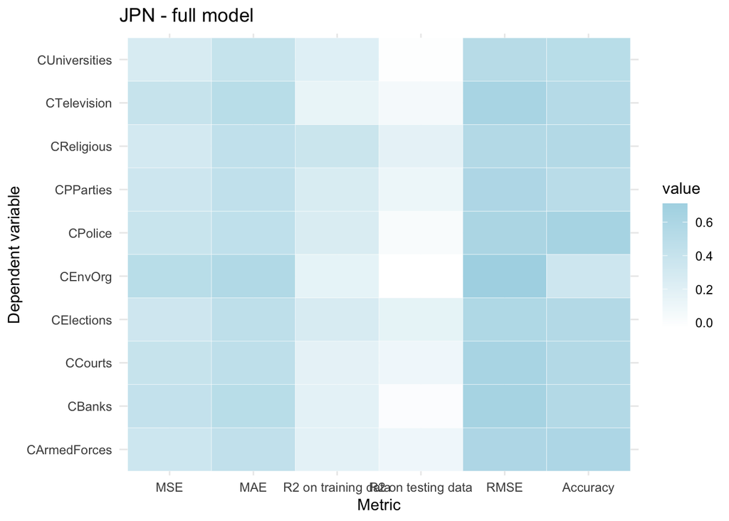

Figure 3: Full model evaluation for JPN

```r
make_metric_heatmap(res_jpn$eval_full, "JPN - full model")
```

Without stepwise selection, `CReligious` and `CElections` are the most reliably predicted variables in Japan, with R² on testing data of 0.17 and 0.16 respectively, meaning the model explains roughly a sixth of the variance in confidence in these two institutions. `CPParties` comes third. On accuracy (predictions rounded to the nearest integer on the target’s own scale), `CPolice` is clearly the strongest at 64.8% correct, followed by `CArmedForces` at 59.7%.

**Stepwise model** (bidirectional AIC selection on top of the full model):

```r
round(res_jpn$eval[, -1], 3)
```

| mse | mae | r_squared_train | r_squared_test | rmse | accuracy |
| --- | --- | --- | --- | --- | --- |
| 0.290 | 0.443 | 0.356 | 0.199 | 0.539 | 0.532 |
| 0.339 | 0.429 | 0.157 | 0.128 | 0.583 | 0.606 |
| 0.386 | 0.498 | 0.122 | 0.086 | 0.621 | 0.528 |
| 0.386 | 0.452 | 0.233 | 0.005 | 0.621 | 0.648 |
| 0.383 | 0.460 | 0.139 | 0.128 | 0.619 | 0.546 |
| 0.346 | 0.456 | 0.241 | 0.109 | 0.588 | 0.491 |
| 0.257 | 0.401 | 0.201 | 0.037 | 0.507 | 0.528 |
| 0.350 | 0.472 | 0.259 | 0.135 | 0.592 | 0.565 |
| 0.415 | 0.500 | 0.167 | 0.018 | 0.644 | 0.542 |
| 0.503 | 0.554 | 0.143 | -0.029 | 0.710 | 0.389 |

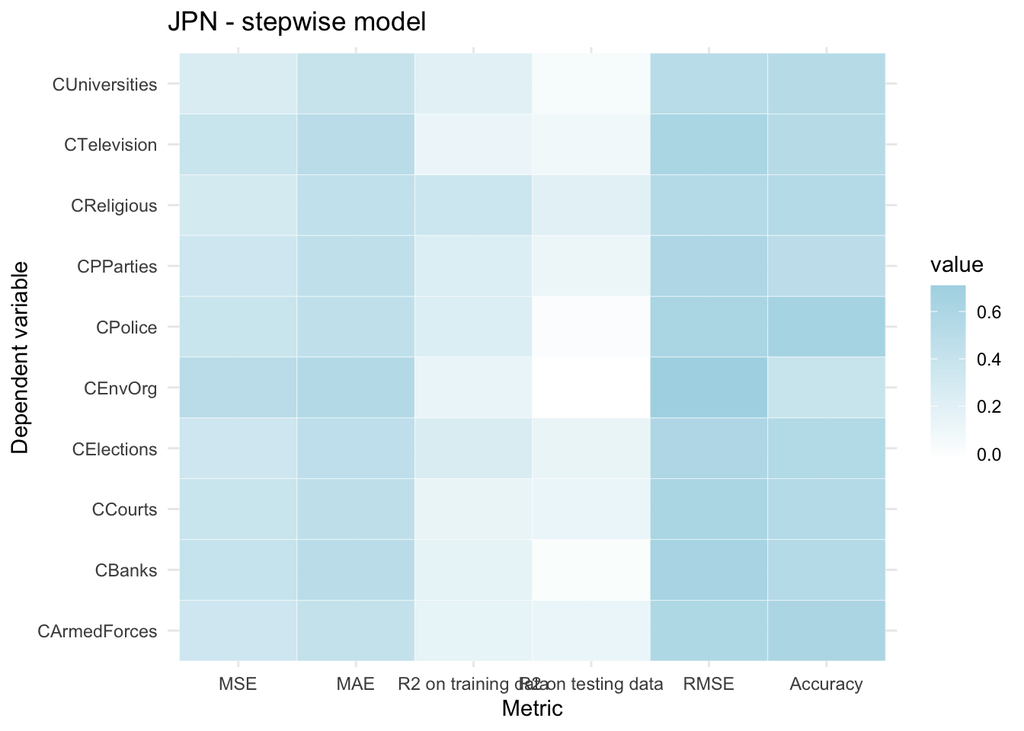

Figure 4: Stepwise model evaluation for JPN

```r
make_metric_heatmap(res_jpn$eval, "JPN - stepwise model")
```

Stepwise selection reduces MSE/MAE/RMSE for most of the ten variables, and R² on testing data increases for most of them too, while R² on training data drops slightly across the board, which is the usual signature of a simpler model that generalises a little better and overfits a little less. `CReligious` remains the best-predicted variable by R² (0.20), now followed by `CElections` and `CCourts`. `CPolice` again has the best accuracy (64.8%, unchanged from the full model), followed by `CArmedForces` (60.6%).

The strongest predictors that `step()` retains, at p < 0.05, for each target variable:

```r
significant_predictors(res_jpn$lst)
```

- CReligious : TNeighbourhood, TMeet, VReligion, PNewspaper
- CArmedForces : TFamily, ECompetition, STRight, PDemCurrent, PSatisfied, Employment
- CTelevision : TPeople, HChoice, PTelevision, PSatisfied
- CPolice : TFamily, ECompetition, STRight, PMobile, PDemCurrent, PSatisfied, Age
- CCourts : TFamily, VWork, EHardWork, PSatisfied
- CPParties : TKnow, VReligion, PTelevision, PSatisfied, Edu
- CUniversities : TKnow, ECompetition, SSecure, PTelevision, PDemCurrent, Employment
- CElections : TPeople, TFamily, VReligion, SSecure, PDemCurrent, PSatisfied, MF, Employment
- CBanks : TFamily, TKnow, SSecure, STImportant, PDemImp, PSatisfied, MF, Age, Edu
- CEnvOrg : TNeighbourhood, TKnow, HFood, PNewspaper, PTelevision

### 4.3 The rest of the world, pooled together

Repeating the same stepwise procedure, but this time training on every country *except* Japan, pooled into a single “Others” group:

```r
res_others = evaluate_group(VC_JPN_Others_raw, "Others", 4002)
round(res_others$eval[, -1], 3)
```

| mse | mae | r_squared_train | r_squared_test | rmse | accuracy |
| --- | --- | --- | --- | --- | --- |
| 0.664 | 0.664 | 0.317 | 0.311 | 0.815 | 0.408 |
| 0.733 | 0.684 | 0.135 | 0.128 | 0.856 | 0.394 |
| 0.652 | 0.657 | 0.134 | 0.134 | 0.807 | 0.445 |
| 0.723 | 0.682 | 0.166 | 0.153 | 0.850 | 0.425 |
| 0.719 | 0.683 | 0.170 | 0.163 | 0.848 | 0.416 |
| 0.634 | 0.638 | 0.189 | 0.184 | 0.796 | 0.431 |
| 0.619 | 0.604 | 0.088 | 0.097 | 0.787 | 0.473 |
| 0.709 | 0.681 | 0.202 | 0.199 | 0.842 | 0.405 |
| 0.769 | 0.720 | 0.112 | 0.098 | 0.877 | 0.388 |
| 0.672 | 0.660 | 0.079 | 0.076 | 0.820 | 0.416 |

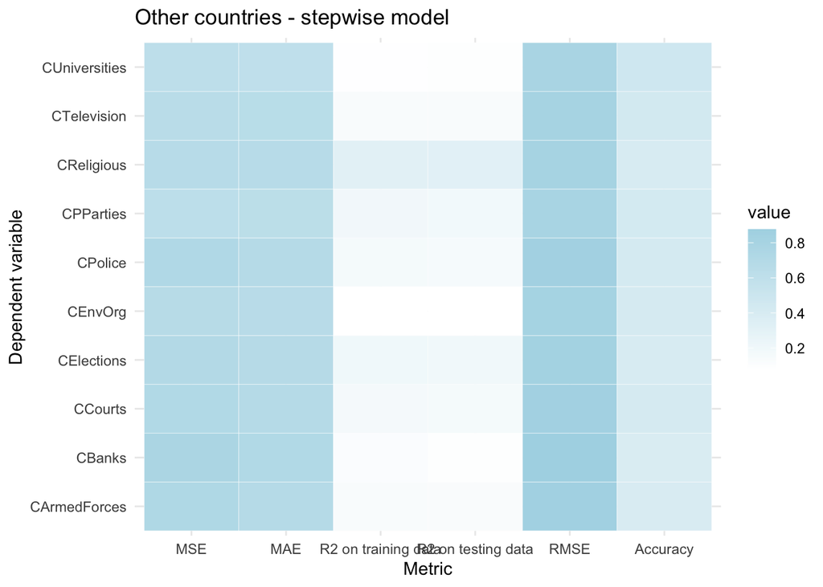

Figure 5: Stepwise model evaluation for other countries

```r
make_metric_heatmap(res_others$eval, "Other countries - stepwise model")
```

The contrast with Japan alone is interesting. Error metrics (MSE, RMSE) are substantially higher here than for Japan alone, which is unsurprising, given “Others” pools together 64 very different countries with very different baseline levels of institutional trust, so there’s simply more variance to explain. But R² on testing data is, for most variables, *higher* than it was for Japan alone: the much larger sample size (tens of thousands of respondents, versus a few hundred for Japan) gives the model more to learn from, even though the group itself is far less homogeneous. `CReligious`, `CElections`, and `CPParties` remain the most reliably predicted variables (the same top three as for Japan’s full model).

```r
significant_predictors(res_others$lst)
```

- CReligious : TPeople, TFamily, TNeighbourhood, TMeet, VFamily, VWork, VReligion, HChoice, HFood, HCrime, EEquality, EHardWork, SSecure, SJob, STRight, STImportant, PNewspaper, PTelevision, PMobile, PDemImp, PDemCurrent, PSatisfied, MF, Age, Edu, Employment
- CArmedForces : TPeople, TFamily, TNeighbourhood, TKnow, VFamily, VReligion, HFood, EEquality, ECompetition, EHardWork, SSecure, STRight, STImportant, PNewspaper, PTelevision, PDemImp, PDemCurrent, PSatisfied, MF, Age, Edu
- CTelevision : TPeople, TFamily, TNeighbourhood, TKnow, TMeet, VWork, VReligion, HChoice, HFood, HShelter, EHardWork, SSecure, SJob, STRight, PNewspaper, PTelevision, PMobile, PDemImp, PDemCurrent, PSatisfied, MF, Age, Edu, Employment
- CPolice : TPeople, TFamily, TNeighbourhood, TKnow, TMeet, VFamily, VReligion, HChoice, HFood, HCrime, HShelter, ECompetition, EHardWork, SSecure, SJob, STRight, STImportant, PNewspaper, PTelevision, PMobile, PDemImp, PDemCurrent, PSatisfied, MF, Age, Edu
- CCourts : TPeople, TFamily, TNeighbourhood, TKnow, TMeet, VFamily, VWork, VReligion, HChoice, HCrime, ECompetition, EHardWork, SSecure, STRight, STImportant, PNewspaper, PTelevision, PMobile, PDemCurrent, PSatisfied, MF, Age, Edu
- CPParties : TPeople, TFamily, TNeighbourhood, TMeet, HChoice, HCrime, HShelter, ECompetition, EHardWork, SSecure, SJob, STRight, STImportant, PNewspaper, PTelevision, PMobile, PDemImp, PDemCurrent, PSatisfied, MF, Age, Edu
- CUniversities : TPeople, TFamily, TNeighbourhood, TKnow, VFamily, VWork, VReligion, HChoice, HShelter, EEquality, ECompetition, EHardWork, SSecure, SJob, STRight, STImportant, PNewspaper, PTelevision, PMobile, PDemImp, PDemCurrent, PSatisfied, Edu, Employment
- CElections : TPeople, TFamily, TNeighbourhood, TKnow, TMeet, VReligion, HChoice, HCrime, EEquality, EHardWork, SSecure, STRight, STImportant, PNewspaper, PTelevision, PDemImp, PDemCurrent, PSatisfied, MF, Age, Edu
- CBanks : TPeople, TFamily, TNeighbourhood, TKnow, TMeet, VWork, VReligion, HChoice, HFood, HCrime, HShelter, EEquality, ECompetition, EHardWork, SSecure, SJob, STRight, STImportant, PNewspaper, PTelevision, PMobile, PDemImp, PDemCurrent, PSatisfied, MF, Age, Edu
- CEnvOrg : TPeople, TFamily, TNeighbourhood, TKnow, TMeet, VWork, HChoice, EEquality, EHardWork, SSecure, SJob, STRight, STImportant, PNewspaper, PTelevision, PMobile, PDemImp, PDemCurrent, PSatisfied, MF, Age, Edu, Employment

The number of statistically significant predictors is much larger here than for Japan alone in almost every model, which is again a sample-size effect: with tens of thousands of observations, even small effects reach significance.

### 4.4 Japan’s cluster of similar countries

Finally, the same procedure again, but training only on the 11 countries identified in Theme 3 as governance-wise similar to Japan (grouped together as “Cluster”, against everyone else):

```r
VC_JPNCluster_Others = VC
VC_JPNCluster_Others$Country = ifelse(VC$Country %in% cluster_countries, "Cluster", "Others")
res_cluster = evaluate_group(VC_JPNCluster_Others, "Cluster", 4003)
round(res_cluster$eval[, -1], 3)
```

| mse | mae | r_squared_train | r_squared_test | rmse | accuracy |
| --- | --- | --- | --- | --- | --- |
| 0.467 | 0.552 | 0.372 | 0.380 | 0.683 | 0.482 |
| 0.534 | 0.562 | 0.124 | 0.126 | 0.731 | 0.499 |
| 0.426 | 0.522 | 0.147 | 0.151 | 0.653 | 0.535 |
| 0.467 | 0.522 | 0.164 | 0.173 | 0.684 | 0.555 |
| 0.521 | 0.567 | 0.159 | 0.147 | 0.722 | 0.505 |
| 0.380 | 0.466 | 0.180 | 0.179 | 0.616 | 0.586 |
| 0.420 | 0.483 | 0.142 | 0.151 | 0.648 | 0.561 |
| 0.537 | 0.586 | 0.244 | 0.220 | 0.733 | 0.473 |
| 0.550 | 0.613 | 0.137 | 0.105 | 0.742 | 0.464 |
| 0.512 | 0.570 | 0.110 | 0.095 | 0.716 | 0.494 |

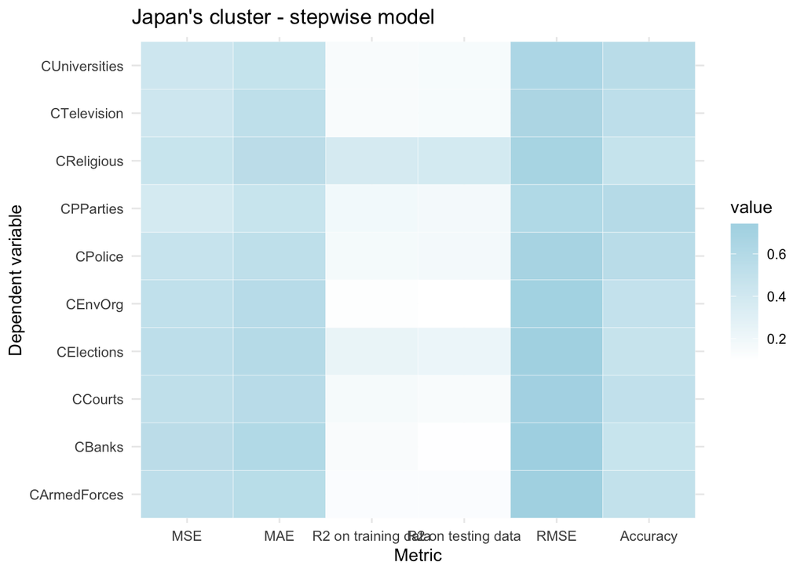

Figure 7: Stepwise model evaluation for Japan’s cluster of similar countries

```r
make_metric_heatmap(res_cluster$eval, "Japan's cluster - stepwise model")
```

```r
significant_predictors(res_cluster$lst)
```

- CReligious : TPeople, TFamily, TNeighbourhood, TKnow, TMeet, VWork, VReligion, HChoice, EEquality, SSecure, SJob, STRight, STImportant, PMobile, PDemImp, PSatisfied, MF, Age
- CArmedForces : TFamily, TNeighbourhood, TKnow, TMeet, VFamily, VReligion, HChoice, HFood, HCrime, EEquality, ECompetition, EHardWork, SJob, STRight, STImportant, PTelevision, PMobile, PDemCurrent, PSatisfied, MF, Edu
- CTelevision : TPeople, TFamily, TNeighbourhood, TMeet, VWork, VReligion, HChoice, HCrime, HShelter, EEquality, ECompetition, EHardWork, PNewspaper, PTelevision, PDemImp, PDemCurrent, PSatisfied, Age, Edu
- CPolice : TPeople, TFamily, TNeighbourhood, TKnow, VFamily, VWork, VReligion, HChoice, EEquality, ECompetition, EHardWork, SSecure, PTelevision, PDemCurrent, PSatisfied, Age, Edu
- CCourts : TPeople, TFamily, TNeighbourhood, TKnow, VFamily, VWork, HCrime, HShelter, EHardWork, SSecure, STImportant, PNewspaper, PTelevision, PDemCurrent, PSatisfied, Edu
- CPParties : TPeople, TFamily, TNeighbourhood, TMeet, VWork, VReligion, HChoice, HShelter, EEquality, ECompetition, SSecure, STRight, PNewspaper, PTelevision, PDemImp, PDemCurrent, PSatisfied, Age, Employment
- CUniversities : TPeople, TFamily, TNeighbourhood, TKnow, VWork, VReligion, HChoice, HCrime, EEquality, EHardWork, SSecure, STRight, STImportant, PTelevision, PMobile, PDemImp, PDemCurrent, PSatisfied, MF, Edu, Employment
- CElections : TPeople, TFamily, TNeighbourhood, TMeet, VFamily, VReligion, HChoice, ECompetition, EHardWork, SSecure, STRight, STImportant, PNewspaper, PTelevision, PMobile, PDemImp, PDemCurrent, PSatisfied, MF, Age, Edu, Employment
- CBanks : TFamily, TNeighbourhood, TKnow, VWork, VReligion, HChoice, HShelter, EEquality, EHardWork, SSecure, SJob, STImportant, PNewspaper, PTelevision, PDemImp, PDemCurrent, PSatisfied, MF, Edu
- CEnvOrg : TPeople, TFamily, TNeighbourhood, TKnow, TMeet, VWork, HChoice, HShelter, EEquality, ECompetition, EHardWork, SSecure, SJob, STRight, PTelevision, PDemImp, PDemCurrent, PSatisfied, MF, Age, Employment

`CReligious`, `CElections`, and `CPParties` are again the three most reliably predicted variables (the same ranking as both the “Others” group and Japan’s own full model).

### 4.5 Cluster vs. the rest of the world: which is the better comparison group?

The real question the assignment poses is whether Japan’s cluster of similar countries gives a *better* match to the predictors that matter for Japan than the undifferentiated “all other countries” group does. Putting the two stepwise tables side by side:

```r
comparison = data.frame(
  Variable = res_others$eval$label_col,
  MSE_others = round(res_others$eval$mse, 3),
  MSE_cluster = round(res_cluster$eval$mse, 3),
  R2test_others = round(res_others$eval$r_squared_test, 3),
  R2test_cluster = round(res_cluster$eval$r_squared_test, 3),
  Accuracy_others = round(res_others$eval$accuracy, 3),
  Accuracy_cluster = round(res_cluster$eval$accuracy, 3)
)
comparison
```

| Variable | MSE_others | MSE_cluster | R2test_others | R2test_cluster | Accuracy_others | Accuracy_cluster |
| --- | --- | --- | --- | --- | --- | --- |
| CReligious | 0.664 | 0.467 | 0.311 | 0.380 | 0.408 | 0.482 |
| CArmedForces | 0.733 | 0.534 | 0.128 | 0.126 | 0.394 | 0.499 |
| CTelevision | 0.652 | 0.426 | 0.134 | 0.151 | 0.445 | 0.535 |
| CPolice | 0.723 | 0.467 | 0.153 | 0.173 | 0.425 | 0.555 |
| CCourts | 0.719 | 0.521 | 0.163 | 0.147 | 0.416 | 0.505 |
| CPParties | 0.634 | 0.380 | 0.184 | 0.179 | 0.431 | 0.586 |
| CUniversities | 0.619 | 0.420 | 0.097 | 0.151 | 0.473 | 0.561 |
| CElections | 0.709 | 0.537 | 0.199 | 0.220 | 0.405 | 0.473 |
| CBanks | 0.769 | 0.550 | 0.098 | 0.105 | 0.388 | 0.464 |
| CEnvOrg | 0.672 | 0.512 | 0.076 | 0.095 | 0.416 | 0.494 |

```r
cat("MSE lower for the cluster in", sum(res_cluster$eval$mse < res_others$eval$mse), "of 10 variables\n")
```

```
## MSE lower for the cluster in 10 of 10 variables
```

```r
cat("R2 (test) higher for the cluster in", sum(res_cluster$eval$r_squared_test > res_others$eval$r_squared_test), "of 10 variables\n")
```

```
## R2 (test) higher for the cluster in 7 of 10 variables
```

```r
cat("Accuracy higher for the cluster in", sum(res_cluster$eval$accuracy > res_others$eval$accuracy), "of 10 variables\n")
```

```
## Accuracy higher for the cluster in 10 of 10 variables
```

The cluster model wins clearly and consistently. Error (MSE) is lower for the cluster on every single one of the ten confidence variables, and accuracy is higher for the cluster on every one of the ten as well. R² on testing data is higher for the cluster on 7 of the 10 variables, and close to tied on the remaining 3. I believe the cluster model gives the better match to the predictors of institutional confidence in Japan, and the likely reason is homogeneity: the cluster is a set of countries with genuinely similar governance quality and institutional context to Japan, so the *relationship* between personal attributes (trust, values, media use, demographics) and institutional confidence looks more similar across that group than it does across “the rest of the world” as an undifferentiated whole, even though the “Others” group has vastly more data to train on.

## Summary of findings

- The dataset is large (50,000 respondents, 65 countries) but unevenly distributed by country, and every numeric variable has a meaningful chunk of missing/non-response codes that need to be handled before modelling (from 0.11% for `MF` up to 6.57% for `CEnvOrg`).
- Japan differs from the rest of the world most clearly on the importance of religion and confidence in religious institutions (both higher), age (older), family importance (slightly lower), frequency of traditional media use (higher), and perceived control over one’s own life (lower).
- A cluster of 11 high-governance-quality democracies (Australia, Canada, Germany, Japan, South Korea, the Netherlands, New Zealand, Taiwan, the UK, the US, and Uruguay), built from World Bank governance indicators, is a meaningfully different comparison group to “the rest of the world” as a whole.
- Across every group tested (Japan alone, the rest of the world, and Japan’s cluster), confidence in religious institutions, elections, and political parties are consistently the most reliably predicted forms of institutional confidence, while confidence in environmental organisations and banks are consistently among the hardest to predict from these attributes.
- Modelling Japan against its cluster of similar countries, rather than against the world as a whole, produces lower error and higher accuracy on every single target variable. This is a strong argument for choosing comparison groups by genuine similarity rather than convenience.

## Appendix: reproducibility notes

A few small, deliberate departures from how I originally ran this analysis, made purely so the whole notebook can be re-run end-to-end and always produce the tables and figures shown above:

- The original analysis was done step-by-step in the R console; some blocks that were re-run interactively (and a few dead-end exploratory lines) have been consolidated here into single, linear functions.
- `step()` is called with `trace = 0` to suppress its per-iteration AIC log, which would otherwise print pages of intermediate output for each of the 30 stepwise models fit in Theme 4.
- The four metric heat maps (Figures 3, 4, 5, 7) are built directly from the `eval` tables computed earlier in the same session, rather than via a manually-edited intermediate CSV file.
- Explicit `set.seed()` calls are placed immediately before the k-means clustering and before each group’s train/test-split loop, so re-knitting this document is fully deterministic.